# Estimating the Financial Impact of Wildfire Smoke on US National parks

## 2.2. Analysis

### 2.2.1. Smoke Effects Past

We subset the data to only include high season visitation for parks in the Inter-mountain and Pacific West regions. The regions projected to be most heavily affected by climate change.

To account for the linear trends of visitation, we first calculated the trends, then found the residuals of each datapoint from the trendline.
$$\begin{aligned}
Resid_{y} &= \begin{cases}y_{obs}-y_{trend}\\ y_{trend} \sim \operatorname{Norm}(\mu_{park},\sigma)\\ \mu_{park} = B_{0}+ B_{1}*X_{1}
\end{cases}
\end{aligned}$$

We then used a hierarchical modeling structure to understand these residuals as a result of the max observed smoke values in each park in each month.
$$\begin{aligned}
Resid_{y} &\sim \begin{cases}\operatorname{Norm}(\mu,\sigma)\\ \mu = B_{0Park}+ B_{1Park}*X_{1Park} \\ \sigma\sim Norm(0,1)
\end{cases}
\end{aligned}$$

This was also operationalized in `rstanarm`

### 2.2.2. Model Validation

### 2.2.3. Smoke, Fee, & Visitation Projections

# 3. Results

## 3.1. Parameter Estimates

For all significant effects (90% C.I. doesn’t overlap 0), we see a negative effect of smoke on the residual visitation to National Parks.

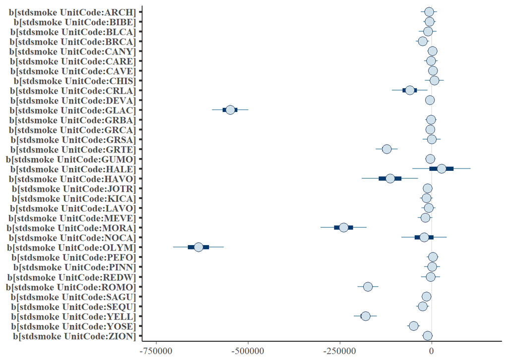